# Module 5 group work

```r
library(ggplot2) #load ggplot
library(ggthemes) #load themes package for ggplot
theme_set(theme_tufte()) # a theme I like.

#set some options that I like
theme_update(plot.title = element_text(hjust = 0.5),
             axis.line.x = element_line(color="black", size = 1),
             axis.line.y = element_line(color="black", size = 1),
             text=element_text(size=20),
             axis.text=element_text(size=15)) #center all titles and and axis lines
```

Load the dataset `BeaverDensities.csv`. This dataset is the counts of beaver colonies of different populations throughout Northern Minnesota (Johnson-Bice et al. 2020). Ecologists are often interested in the degree of synchrony (correlation) in populations over space.

1. Calculate the correlations between populations.
2. Use the `corrplot` library to plot these correlations. Do the correlations between populations tend to be positive, negative, or both?

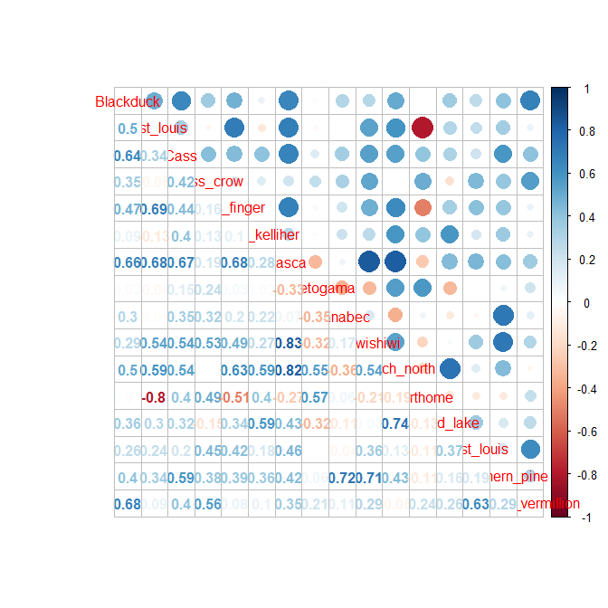

```r
#code here
beaver.dat <- read.csv(file="../Data/BeaverDensities.csv")
M <- cor(beaver.dat[,-1], use="pairwise.complete")
library(corrplot)
corrplot.mixed(M)
```

### Populations tend to be positively correlated. This is as we would expect for synchronous populations.

Now load a datast that has these correlations and the distances between each population (`CorrDistance.csv`). Test to see whether correlation between populations varies by distance in a predictable manner. What information from the regression output did you use to draw your conclusions?

```r
#code here
corrdist.dat <- read.csv(file="../Data/CorrDistance.csv")

confint(lm(correlation ~ distance, data=corrdist.dat))
```

```
                    2.5 %       97.5 %
(Intercept)  1.055345e-01 3.935648e-01
distance    -3.918658e-07 9.874464e-07
```

### Based on the 95% confidence interval, a slope of 0 for the distance effect is plausible. Thus, we do not see that population correlations increase or decrease with distance.

The data set contained in `LionNoses.csv` contains the age of male lions and the proportion of their nose that is black (from Whitman et al. 2004). The proportional amount of black on a lions nose tends to change as an individual ages, a pattern that can be used to identify individual lions (http://livingwithlions.org/mara/how-to/identify-lions/).

Load this dataset and create a linear model to relate the proportion blackness in a lions nose to it’s age. Interpret the slope, intercept, any significance tests, and the $R^2$ value.

```r
#code here
nose.dat <- read.csv(file="../Data/LionNoses.csv")

summary(lm(ageInYears ~ proportionBlack, data=nose.dat))
```

```
Call:
lm(formula = ageInYears ~ proportionBlack, data = nose.dat)

Residuals:
    Min      1Q  Median      3Q     Max
-2.5449 -1.1117 -0.5285  0.9635  4.3421

Coefficients:
                Estimate Std. Error t value Pr(>|t|)
(Intercept)       0.8790     0.5688   1.545    0.133
proportionBlack  10.6471     1.5095   7.053 7.68e-08 ***
---
Signif. codes:
0 ‘***’ 0.001 ‘**’ 0.01 ‘*’ 0.05 ‘.’ 0.1 ‘ ’ 1

Residual standard error: 1.669 on 30 degrees of freedom
Multiple R-squared:  0.6238,    Adjusted R-squared:  0.6113
F-statistic: 49.75 on 1 and 30 DF,  p-value: 7.677e-08
```

### The slope indicates that a unit increase (here a 100% increase in black) corresponds to an increase in 10 years of a lion. The intercept indicates that a lion with no black on their nose is 0.87 years old. The significance tests indicate that we cannot reject the possibility that the intercept is 0, but the slope does differ from 0. The $R^2$ value tells us that we are explaining 62% of the variation in our data.

Sometimes when our model diagnostics suggest that assumptions of the model are not being met, transforming the data will improve these properties.

1. Read in the dataset, `monet.csv`. Build a model that includes SIGNED (whether the painting was signed) and SIZE. Does the diagnostic plot of predicted values versus the residuals suggest that the variance changes with the predicted mean?

```r
monet.dat <- read.csv(file="../Data/monet.csv")
monet.dat <- subset(monet.dat, SIZE <1500 ) #super large paintings seem to behave differently than the rest so we will only look at a subset of them
#code here
monet.lm <- lm(PRICE ~ SIZE + SIGNED, data=monet.dat)
summary(monet.lm)
```

```
Call:
lm(formula = PRICE ~ SIZE + SIGNED, data = monet.dat)

Residuals:
    Min      1Q  Median      3Q     Max
-5.6002 -2.1008 -0.8928  0.7735 26.1396

Coefficients:
              Estimate Std. Error t value Pr(>|t|)
(Intercept) -3.6949671  0.6956815  -5.311 1.83e-07 ***
SIZE         0.0063321  0.0007175   8.826  < 2e-16 ***
SIGNEDYes    1.8369360  0.5484086   3.350 0.000888 ***
---
Signif. codes:
0 ‘***’ 0.001 ‘**’ 0.01 ‘*’ 0.05 ‘.’ 0.1 ‘ ’ 1

Residual standard error: 3.828 on 393 degrees of freedom
Multiple R-squared:  0.2065,    Adjusted R-squared:  0.2024
F-statistic: 51.13 on 2 and 393 DF,  p-value: < 2.2e-16
```

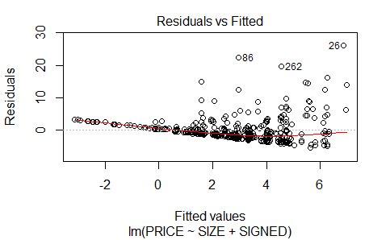

```r
plot(monet.lm, which=1)
```

### There is definitely an increase in the variance with the fitted means.

Now try log-transforming PRICE in your model. Does this lead to a residual plot that looks consistent with the assumptions of linear regression?

```r
monet.lm <- lm(log(PRICE) ~ SIZE + SIGNED, data=monet.dat)
summary(monet.lm)
```

```
Call:
lm(formula = log(PRICE) ~ SIZE + SIGNED, data = monet.dat)

Residuals:
    Min      1Q  Median      3Q     Max
-3.9452 -0.6487 -0.0421  0.7017  2.9417

Coefficients:
              Estimate Std. Error t value Pr(>|t|)
(Intercept) -2.9617610  0.1776614  -16.67   <2e-16 ***
SIZE         0.0024228  0.0001832   13.22   <2e-16 ***
SIGNEDYes    1.5090185  0.1400512   10.78   <2e-16 ***
---
Signif. codes:
0 ‘***’ 0.001 ‘**’ 0.01 ‘*’ 0.05 ‘.’ 0.1 ‘ ’ 1

Residual standard error: 0.9777 on 393 degrees of freedom
Multiple R-squared:  0.4711,    Adjusted R-squared:  0.4684
F-statistic: 175.1 on 2 and 393 DF,  p-value: < 2.2e-16
```

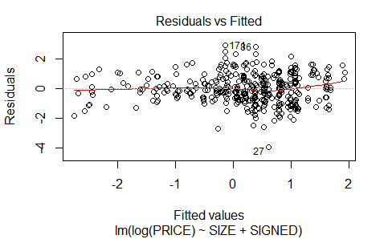

```r
plot(monet.lm, which=1)
```

### The log-transformed data look like a much better fit than the original data.

Based on your model does having a signed painting increase it’s value? Load the `sjPlot` library and plot log(PRICE) predictions against SIZE and SIGNED predictors. Does the plot agree with your interepretation of the parameter estimates?

```
Model has log-transformed response. Back-transforming predictions to original response scale. Standard errors are still on the log-scale.
```

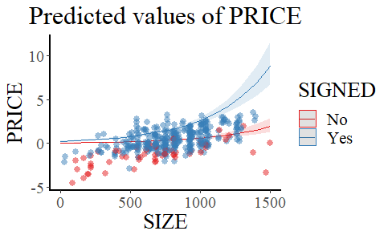

```r
library(sjPlot)
plot_model(monet.lm, type="pred", terms=c("SIZE", "SIGNED"), show.data=TRUE)
```

### Based on the above plot, signed paintings are more valuable than unsigned paitings of the same size. Our model captures this, though the prices of large unsigned paintings appear to be too high.

Finally, build a model to test whether log(PRICE) increases faster in signed paintings than unsigned paintings using an interaction term in your model. What information from the model output did you use to obtain your decision?

```r
#code here
monet.lm <- lm(log(PRICE) ~ SIZE * SIGNED, data=monet.dat)
confint(monet.lm)
```

```
                       2.5 %        97.5 %
(Intercept)    -3.4327730577 -2.3587751197
SIZE            0.0016231003  0.0030273713
SIGNEDYes       0.7709354379  2.0586714707
SIZE:SIGNEDYes -0.0006858252  0.0009508265
```

### Based on the confidence interval of the interaction term, hte data are consistent with having no difference in the slope of signed and unsigned paintings on log-price.

Load the `BlackBears.csv` dataset and build a boxplot of AGE against LBS. Does it look like the assumptions of ANOVA will be met with these data? Now try log-transforming the data. Does this improve the consistency of the data with ANOVA assumptions? Now run an ANOVA on the response data you think best fit the assumptions of the ANOVA. Do at least one of these groups differ from the others?

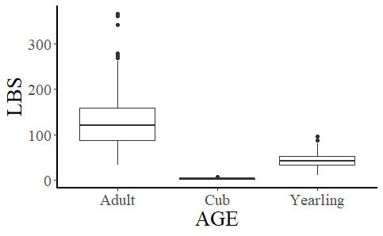

```r
#code here
bear.dat <- read.csv(file="../Data/BlackBears.csv")

ggplot(data=bear.dat) +
  geom_boxplot(aes(x=AGE, y=LBS))
```

### These groups do not have equal variance so an ANOVA would be problematic.

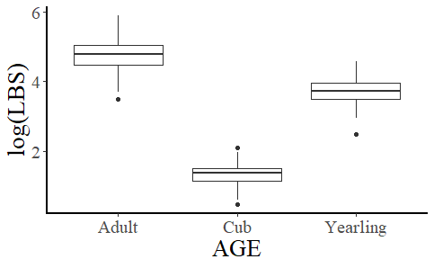

```r
ggplot(data=bear.dat) +
  geom_boxplot(aes(x=AGE, y=log(LBS)))
```

### The log-transformed data look much better so we will run the ANOVA on these. We find that there is a difference among the groups (at $\alpha=0.05$).

```r
summary(aov(log(LBS) ~ AGE, data=bear.dat))
```

```
             Df Sum Sq Mean Sq F value Pr(>F)
AGE           2 1045.8   522.9    3309 <2e-16 ***
Residuals   515   81.4     0.2
---
Signif. codes:
0 ‘***’ 0.001 ‘**’ 0.01 ‘*’ 0.05 ‘.’ 0.1 ‘ ’ 1
```

Now do a post-test to determine which (if any) of the stage classes differs from the others.

```r
#code here
TukeyHSD(aov(log(LBS) ~ AGE, data=bear.dat))
```

```
  Tukey multiple comparisons of means
    95% family-wise confidence level

Fit: aov(formula = log(LBS) ~ AGE, data = bear.dat)

$AGE
                    diff       lwr        upr p adj
Cub-Adult      -3.433485 -3.532696 -3.3342745     0
Yearling-Adult -1.026817 -1.134828 -0.9188065     0
Yearling-Cub    2.406668  2.282303  2.5310323     0
```